# 05_Davis_Shannon_2018

Shannon Davis

October 9, 2018

## 1. W&S ??2 questions

### 8.12

#### a. calculate the fraction of b alleles in the population.

```r
BB <- 42
Bb <- 24
bb <- 21

b_prob = (0*BB + 1*Bb + 2*bb)/ (2*(BB+Bb+bb))

b_prob
```

```
## [1] 0.3793103
```

#### b. With your estimate of the fraction of b alleles, and assuming a binomial distribution calculate the expected frequency of bers with 0, 1 and 2 copies.

```r
b_exp = dbinom(0:2, size=2, prob=b_prob)
exp_dist = 87*b_exp
exp_dist
```

```
## [1] 33.51724 40.96552 12.51724
```

#### c. Compare the observed and expected frequencies in a graph. Describe how they differ.

```r
obs_dist = c(42,24,21)
results = rbind(obs_dist,exp_dist)

results
```

```
##              [,1]     [,2]     [,3]
## obs_dist 42.00000 24.00000 21.00000
## exp_dist 33.51724 40.96552 12.51724
```

```r
str(results)
```

```
##  num [1:2, 1:3] 42 33.5 24 41 21 ...
##  - attr(*, "dimnames")=List of 2
##   ..$ : chr [1:2] "obs_dist" "exp_dist"
##   ..$ : NULL
```

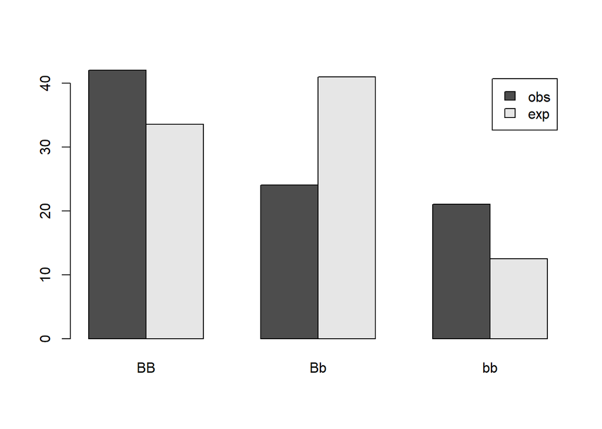

```r
colnames(results) = c("BB","Bb","bb")
barplot(results, beside=TRUE, legend.text=c("obs","exp"))
```

### 8.24

#### a. graph the relative frequency distribution for these results. What type of graph is ideal?

```r
#growth <- read_csv("../Data/chap08q24DodderGrowth.csv")

#head(growth)

growth2 <- data.frame("direction_of_growth" = c("away from volatile", "left", "right", "toward volatile"), "freq" = c(2,7,4,17))

growth2
```

```
##   direction_of_growth freq
## 1  away from volatile    2
## 2                left    7
## 3               right    4
## 4     toward volatile   17
```

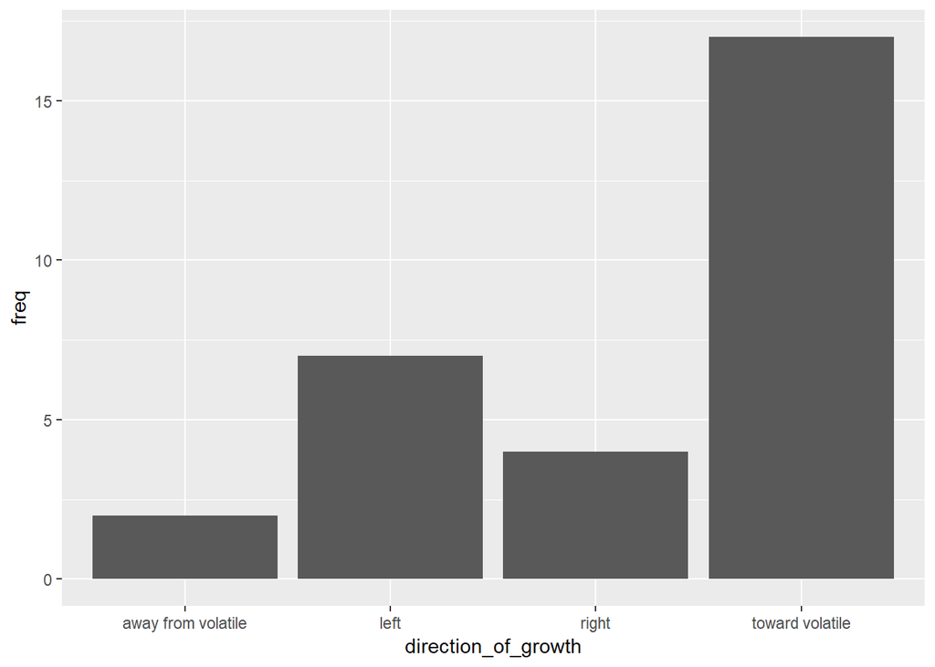

```r
#frequency of growth
freq_grow <- ggplot(data = growth2,
                      mapping = aes(x = direction_of_growth, y= freq)) +
 geom_col()

freq_grow
```

```r
#relative frequency
growth_freq <- growth2 %>%
  mutate(rel_freq = growth2$freq/30) %>%
  ungroup()

growth_freq
```

```
##   direction_of_growth freq   rel_freq
## 1  away from volatile    2 0.06666667
## 2                left    7 0.23333333
## 3               right    4 0.13333333
## 4     toward volatile   17 0.56666667
```

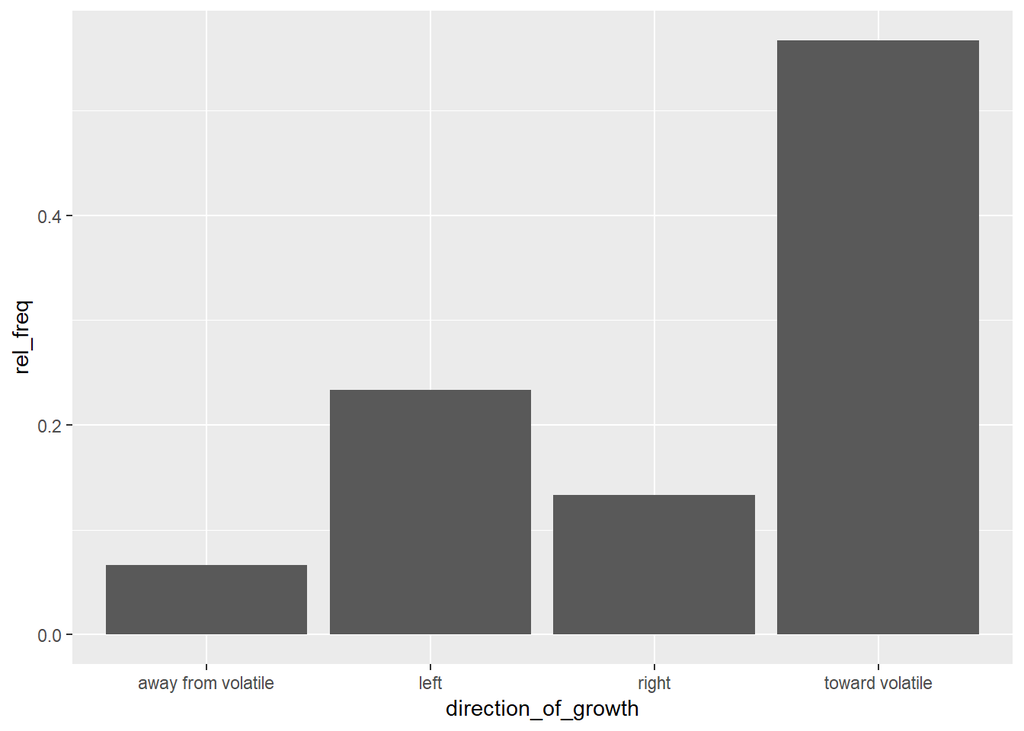

```r
#graph relative frequencies

rel_freq_plot <- ggplot(data = growth_freq,
                      mapping = aes(x = direction_of_growth,
                                    y = rel_freq))+
geom_col()

rel_freq_plot
```

The idea graph is a column chart so that the relationship between the 4 options can be seen.

#### b. What are the relative frequencies expected if the parasite is unable to detect the plant volatiles or any other cues present? Add these expected relative frequencies to your graph in part a

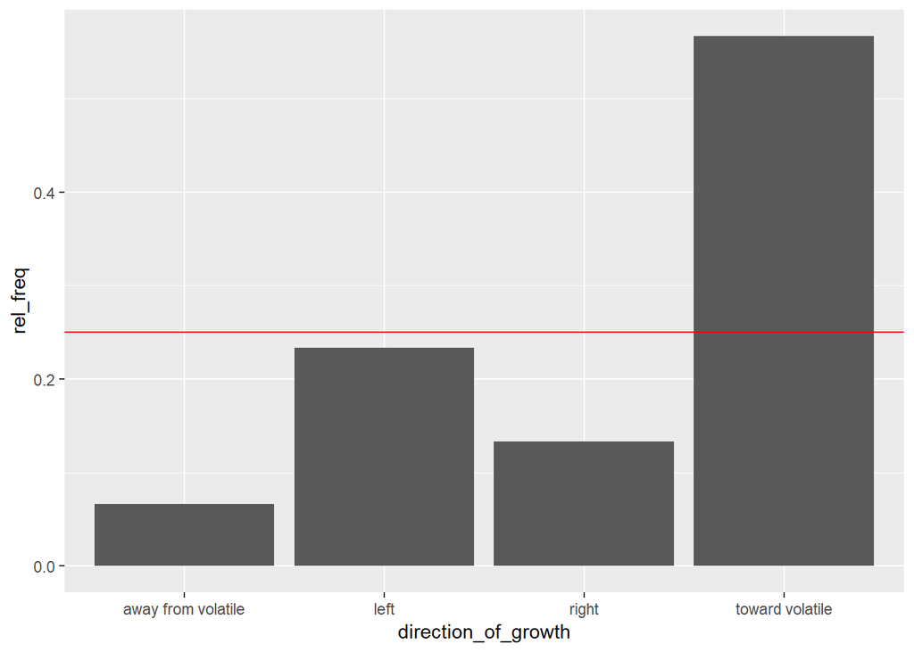

```r
#add in expceted freq (all 0.25)
growth_exp_obs <- growth_freq %>%
  mutate(exp = c(1/4,1/4,1/4,1/4)) %>%
  ungroup()

#plot both obserevd and expected
exp_plot <-
  ggplot(growth_exp_obs,
       mapping = aes(x = direction_of_growth, y = rel_freq)) +
  geom_col()+
  geom_hline(yintercept = 0.25, color = "red")


exp_plot
```

I could not figure out how to make this barchart work without transforming the table, so the expected values are represented by the red line at 0.25.

#### c. Using the data, calculate the fraction of seedlings that grow toward the colatiles. What does this estimate?

```r
grow_volatile <- (17/30)

grow_volatile
```

```
## [1] 0.5666667
```

This is the proportion of dodders, in our sample, that grow toward the volatiles. This is the liklihood of a plant growing toward the volatiles in our sample.

#### d. Provide a standard error for your estimate. What does this standard error represent?

```r
SE_vol <- sqrt((grow_volatile*(1-grow_volatile))/30)

SE_vol
```

```
## [1] 0.09047201
```

The standard error is telling us the accuracy of how well the sample represents the population mean, This has a low standard error meaning it represents the population well.

#### e. calculate the range of most-plausible values fot the fraction of dodder seedlings that grow toward the colatiles under these experimental conditions. Does it inculde or exclude the fraction expected if the parasite is unable to ditect plant volatiles or other cues present?

```r
CI_grow <- 1.96 * SE_vol # 95 CI  estimate

CI_lower_grow <- grow_volatile - 2*CI_grow
CI_upper_grow <- grow_volatile + 2*CI_grow


CI_lower_grow
```

```
## [1] 0.2120164
```

```r
CI_upper_grow
```

```
## [1] 0.921317
```

### 9.16

#### a Calculate expected frequencies for contingency test

```r
prairie <- read_csv("../Data/chap09q16PrairieDogMultipleMating.csv")
head(prairie)
```

```
## # A tibble: 6 x 2
##   matingFrequency gaveBirth
##             <int> <chr>
## 1               1 yes
## 2               1 yes
## 3               1 yes
## 4               1 yes
## 5               1 yes
## 6               1 yes
```

```r
con_test_prairie <- chisq.test(prairie$matingFrequency, prairie$gaveBirth, correct = FALSE)
con_test_prairie
```

```
##
##  Pearson's Chi-squared test
##
## data:  prairie$matingFrequency and prairie$gaveBirth
## X-squared = 7.078, df = 4, p-value = 0.1318
```

```r
con_test_prairie$expected
```

```
##                        prairie$gaveBirth
## prairie$matingFrequency        no      yes
##                       1 4.6311787 82.36882
##                       2 4.9505703 88.04943
##                       3 3.2471483 57.75285
##                       4 0.9049430 16.09506
##                       5 0.2661597  4.73384
```

#### b. Examine the expected frequencies. Do they meet the assumptions of the X^2 contingency est? If not, what steps could you take to meet the assumptions and make a test?

No they do not meet the assumptions of the X^2 test (there are values less than 1). You could combine catagories to get a bigger sample size per group. So have less than 3 mates and more than 3 mate.

#### c. An appropriate test shows that the number of mates of the female praire dog is associated with giving birth. DOes this mean that mating with more males increase the probability of giving birth? Can you think of an alternative explanation?

Another explanation could be the more times (not differnt mates) increases the liklyhood of getting fertilized.

### 9.27

```r
widow<- read_csv("../Data/chap09q27WidowHealth.csv")
head(widow)
```

```
## # A tibble: 6 x 2
##   health_deterioration widowed
##   <chr>                <chr>
## 1 marked               yes
## 2 marked               yes
## 3 marked               yes
## 4 marked               yes
## 5 marked               yes
## 6 marked               yes
```

```r
chisq.test(widow$health_deterioration, widow$widowed, correct=FALSE)
```

```
##
##  Pearson's Chi-squared test
##
## data:  widow$health_deterioration and widow$widowed
## X-squared = 11.177, df = 2, p-value = 0.00374
```

The p value is less than alpha = 0.05 (it is 0.00374), so therfore we regect the null hypothesis. The probability of health deterioation is realted to if a person is widowed.

## 2. W&S t-test questions

### 11.21

#### a. Draw a graph of the data, following recomended principles of good graph design. What trend is sugested?

```r
soil<- read_csv("../Data/chap11q21SoilLeadAndHurricanes.csv")
head(soil)
```

```
## # A tibble: 6 x 6
##    Site Soil_lead_Before_Katr~ Soil_lead_After_Katr~ Change Ratio LogRatio
##   <int>                  <int>                 <int>  <int> <dbl>    <dbl>
## 1     1                    711                   310   -401 0.436    -0.83
## 2    10                     37                    31     -6 0.838    -0.18
## 3    11                     46                    53      7 1.15      0.14
## 4    12                     90                    21    -69 0.233    -1.46
## 5    13                   1049                   648   -401 0.618    -0.48
## 6    14                    247                    87   -160 0.352    -1.04
```

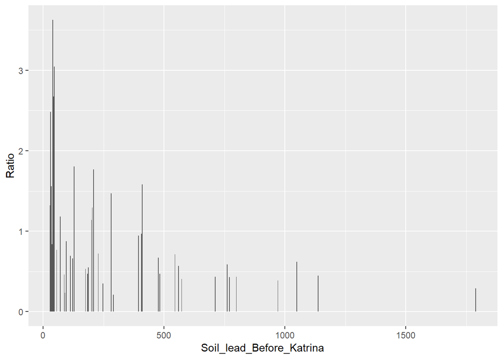

```r
soil_plot <- ggplot(data = soil,
                     mapping = aes(x = Soil_lead_Before_Katrina, y = Ratio))+
geom_col()

soil_plot
```

### 12.20

### 12.26

### 12.30

## 3. Power and T

### In class, we worked through an example of power via simulation for a two-sample t-test with equal variance and sample size. Let’s go through a similar exercise, but this time, assuming we have a situation with both different sample sizes and variances.

## 3.1 Data Generating Process

### Write a function that takes two means, two standard deviations, and two sample sizes as arguments. Have it return a data frame or tibble based on the inputs ready to go for a t-test!

```r
make_t_data <- function(m1, m2, s1, s2, n1, n2){
  data.frame(group = c(rep("A", n1), rep("B",n2)),
             value = rnorm(n1+n2,
                           mean = c(rep(m1, n1), rep(m2, n2)),
                           sd = c(rep(s1, n1), rep(s2, n2))),
             stringsAsFactors = FALSE)
}

test_case <- make_t_data(1, 2, 1, 2, 3, 5)

test_case
```

```
##   group       value
## 1     A -0.04965242
## 2     A  2.06196548
## 3     A -0.33294393
## 4     B  3.50456899
## 5     B  2.10338827
## 6     B  2.91257008
## 7     B  4.46178093
## 8     B  5.56685512
```

## 3.2 P From T

### Write a function that takes a data frame and runs a two-tailed t-test with the variances assumed to be unequal. Show it works by comparing it’s p-value to that returned by t-test for the same simulated data set. Note, if you gave particular column names in the function from 3.1, you should use those here! If you are stumped on how to get a p-value, look at the help file for t.test, remembering that the output from t.test is a list! +2 Extra credit, look at ?ifelse or ?“if” and use one of them to have your function choose to use unequal variances if your variances differ by 20%.

```r
get_p_from_t_test <- function(sim_data){
test<- t.test(value ~ group, data = sim_data, alternative = (c("two.sided")))
test$p.value
}

get_p_from_t_test(test_case)
```

```
## [1] 0.02658843
```

```r
#use t.test to get p -value
t.test(test_case$value)
```

```
##
##  One Sample t-test
##
## data:  test_case$value
## t = 3.4956, df = 7, p-value = 0.01005
## alternative hypothesis: true mean is not equal to 0
## 95 percent confidence interval:
##  0.8180768 4.2390564
## sample estimates:
## mean of x
##  2.528567
```

## 3.3 So many Ps!

### Write a function that takes takes some number of simulations, two means, two standard deviations, and two sample sizes as arguments and returns a vector of p values equal in length to that number of simulations. It should call your functions from 3.1 and 3.2 using replicate() or purrr::rerun() or some other strategy to do something many times. Your call! **Extra credit - try it different ways and show using a large number of simulations and system.time() or the profileR package which way is faster.

```r
Many_P <- function (m1, m2, s1, s2, n1, n2, nsim){
  (replicate(nsim, get_p_from_t_test(make_t_data(m1, m2, s1, s2, n1, n2))))
}

Many_P(1, 2, 1, 2, 3, 5, 10)
```

```
##  [1] 0.1371133 0.9277299 0.8034251 0.3064022 0.2850170 0.9361274 0.6394877
##  [8] 0.2385814 0.5453392 0.9559182
```

## 3.4 I have the power

### Write a function that takes an alpha value, some number of simulations, two means, two standard deviations, and two sample sizes as argument, and returns the power. It should call the function you wrote in 3.3. Now, make sure this works by comparing your results to the appropriate call to power.t.test(). Do they agree? Why or why not?

```r
get_t_power <- function(m1, m2, s1, s2, n1, n2, nsim = 100, alpha = 0.07){
  p <- Many_P(m1, m2, s1, s2, n1, n2, nsim)
  num_wrong <- sum(p > alpha)

  1- num_wrong/nsim
}

get_t_power(1, 2, 1, 2, 3, 5, 100, 0.07)
```

```
## [1] 0.12
```

```r
#no power.t.test (cant take 2 sds)
```

## 3.5 Show it works

### Using your functions from above, explore how changing the difference between the the means of two groups interacts with the difference between two standard deviations of groups to affect the power of a t-test. Explain the results you produce. +1 Extra credit for using a color scheme from the wesanderson or beyonce package that is illuminating.

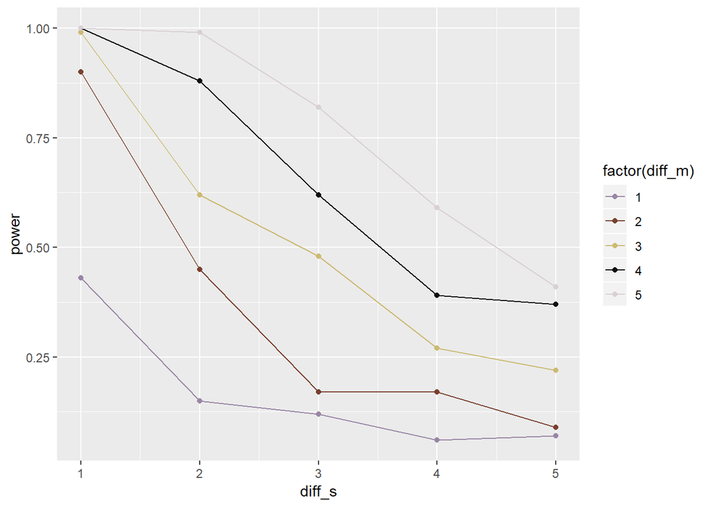

```r
library(wesanderson)

pow_df <- crossing(diff_m = 1:5, diff_s = 1:5, n1 = 3, n2 = 5) %>%
  rowwise() %>%
  mutate(power = get_t_power(m1 = 0, m2 = diff_m, s1 = 0, s2 = diff_s, n1 = n1, n2 = n2, nsim=100, alpha=0.05)) %>%
  ungroup()

plot<- ggplot(data = pow_df,
                      mapping = aes(x =diff_s, y = power, color = factor(diff_m)))+
  geom_point()+
  geom_line()+
  scale_color_manual(values = wes_palette(18))

plot
```

As the diff_s goes up the power goes down. As the diff_m goes up the power goes up. This means that deiffernece of sd is negativly corrilated to power and mean is positivly correlated.

## 3.6 Extra Credit

### +2 Extra credit if you include a comparison between running the test with versus without equal variances - this might require you to re-write your function from 3.2 to include an argument where you specify if you want equal or unequal variance tests to be used. +1 additional extra credit for folding this into your auto-detect unequal variance function from above, but have this argument override the automatic detection of equal or unequal variances. Lots of ways to do this, some more efficient than others.

## 4. Extra Credit on Contingency Tables (3 points)

### Write a function that takes a count data frame in with 2 columns of categorical predictors (characters) and 1 of counts, and returns a ??2 test for the appropriate contingency table. +1 more if it also outputs the contingency table. +3 more if it works for an n x n x n x n x .. contingency table. Show it works by comparing the results to using xtabs() and chisq.test(). You should look at the formulae in W&S here to help you.